# Predicting Stock Return using ARIMA model

Phuoc Tran

2022-10-24

### Data Cleaning & Validation

Initially, all essential package for the time-series manipulation, analysis and forecast will be installed

```r
library(tidyverse)
library(dplyr)
library(magrittr)
library(knitr)
library(anytime)
library(pastecs)
library(tsibble)
library(DescTools)
library(forecast)
library(fabletools)
library(feasts)
library(stats)
library(tseries)
library(fable)
```

The historical data of ACB and EIB were downloaded from Investing.com then imported to R:

```r
ACB_raw <- read.csv("/Users/phuoctran/Desktop/Personal Projects/Forecasting Stock Returns using ARIMA/ACB Historical Data.csv")
EIB_raw <- read.csv("/Users/phuoctran/Desktop/Personal Projects/Forecasting Stock Returns using ARIMA/EIB Historical Data.csv")
```

Examine whether two datasets contain any null value:

```r
is.null(ACB_raw)
```

```
## [1] FALSE
```

```r
is.null(EIB_raw)
```

```
## [1] FALSE
```

Since the console returns “FALSE” for both datasets, there is no null value

Next, check class type of each variables:

```r
str(ACB_raw)
```

```
## 'data.frame':    574 obs. of  7 variables:
##  $ Date    : chr  "Jul 31, 2022" "Jul 24, 2022" "Jul 17, 2022" "Jul 10, 2022" ...
##  $ Price   : chr  "24,850.0" "24,600.0" "24,350.0" "24,000.0" ...
##  $ Open    : chr  "24,650.0" "24,200.0" "24,100.0" "23,850.0" ...
##  $ High    : chr  "25,250.0" "24,700.0" "24,900.0" "24,450.0" ...
##  $ Low     : chr  "24,500.0" "23,900.0" "23,800.0" "23,500.0" ...
##  $ Vol.    : chr  "21.59M" "11.39M" "13.32M" "8.56M" ...
##  $ Change..: chr  "1.02%" "1.03%" "1.46%" "0.00%" ...
```

```r
str(EIB_raw)
```

```
## 'data.frame':    573 obs. of  7 variables:
##  $ Date    : chr  "Jul 31, 2022" "Jul 24, 2022" "Jul 17, 2022" "Jul 10, 2022" ...
##  $ Price   : chr  "30,400.0" "30,000.0" "30,800.0" "30,950.0" ...
##  $ Open    : chr  "30,500.0" "30,800.0" "30,700.0" "31,200.0" ...
##  $ High    : chr  "31,150.0" "30,900.0" "31,000.0" "31,400.0" ...
##  $ Low     : chr  "29,900.0" "29,750.0" "30,450.0" "30,500.0" ...
##  $ Vol.    : chr  "1.25M" "1.21M" "738.80K" "768.70K" ...
##  $ Change..: chr  "1.33%" "-2.60%" "-0.48%" "-0.64%" ...
```

Owing to all variables are classifed as character, which are unable to be calculated and plotted, a class transformation is needed. Initially, the Date column will be transformed to class Date by using as.Date function:

```r
ACB_asdate <- anydate(ACB_raw$Date) %>% as.Date(format("%d/%m/%Y"))
EIB_asdate <- anydate(EIB_raw$Date) %>% as.Date(format("%d/%m/%Y"))
```

Next, the Price, Open, High, Low columns are turned into numeric class with as.Numeric function. Nevertheless, the comma in the figure needs to be removed first by using gsub() function:

```r
ACB_numeric <- as.data.frame(apply(ACB_raw[,c(2:5)], 2, function(ACB_raw) {as.numeric(gsub(",", "", ACB_raw))}))
EIB_numeric <- as.data.frame(apply(EIB_raw[,c(2:5)], 2, function(EIB_raw) {as.numeric(gsub(",", "", EIB_raw))}))
```

Similarly, the “Change %” column is transformed into numeric class after removing the “%”, and formatting into deccimal by dividing with 100:

```r
ACB_change_numeric <- gsub("%","",ACB_raw$Change..) %>% as.numeric()/100
EIB_change_numeric <- gsub("%","",EIB_raw$Change..) %>% as.numeric()/100
```

After the class transformation, all the variables will be re-joint into a new dataframe:

```r
ACB <- data.frame("Date" = ACB_asdate,
                  "Price" = ACB_numeric$Price,
                  "Open" = ACB_numeric$Open,
                  "High" = ACB_numeric$High,
                  "Low" = ACB_numeric$Low,
                  "Change %" = ACB_change_numeric)

EIB <- data.frame("Date" = EIB_asdate,
                  "Price" = EIB_numeric$Price,
                  "Open" = EIB_numeric$Open,
                  "High" = EIB_numeric$High,
                  "Low" = EIB_numeric$Low,
                  "Change %" = EIB_change_numeric)
```

Double check the structure of the new dataframes:

```r
str(ACB)
```

```
## 'data.frame':    574 obs. of  6 variables:
##  $ Date    : Date, format: "2022-07-31" "2022-07-24" ...
##  $ Price   : num  24850 24600 24350 24000 24000 ...
##  $ Open    : num  24650 24200 24100 23850 24400 ...
##  $ High    : num  25250 24700 24900 24450 24600 ...
##  $ Low     : num  24500 23900 23800 23500 23600 ...
##  $ Change..: num  0.0102 0.0103 0.0146 0 -0.0021 0.0105 0.0303 -0.0833 -0.004 -0.0055 ...
```

```r
str(EIB)
```

```
## 'data.frame':    573 obs. of  6 variables:
##  $ Date    : Date, format: "2022-07-31" "2022-07-24" ...
##  $ Price   : num  30400 30000 30800 30950 31150 ...
##  $ Open    : num  30500 30800 30700 31200 32750 ...
##  $ High    : num  31150 30900 31000 31400 32750 ...
##  $ Low     : num  29900 29750 30450 30500 30250 ...
##  $ Change..: num  0.0133 -0.026 -0.0048 -0.0064 -0.0386 0.0302 0.0032 0.0313 -0.0349 -0.0762 ...
```

Reverse the dataframe order so that the Date can be from oldest to latest:

```r
ACB_sorted <-  ACB[nrow(ACB):1, ]
EIB_sorted  <- EIB[nrow(EIB):1, ]
```

Plotting the price chart of two stocks

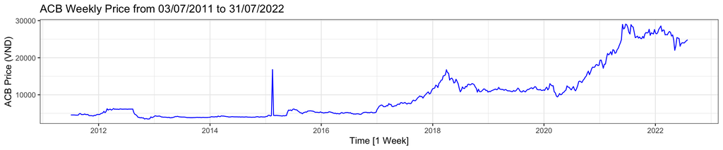

```r
#ACB Price plot
ACB_sorted %>% ggplot() + aes(x = `Date`, y =`Price`,group = 1) +
  geom_line(color = "blue", size = 0.5) +
  ggtitle("ACB Weekly Price from 03/07/2011 to 31/07/2022") +
  theme_bw() + xlab("Time [1 Week]") + ylab("ACB Price (VND)")
```

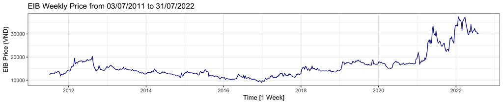

```r
#EIB Price plot
EIB_sorted %>% ggplot() + aes(x = `Date`, y =`Price`,group = 1) +
  geom_line(color = "navy", size = 0.5) +
  ggtitle("EIB Weekly Price from 03/07/2011 to 31/07/2022") +
  theme_bw() + xlab("Time [1 Week]") + ylab("EIB Price (VND)")
```

It seems that ACB price data has invalid data point according to its abnormal spike in early 2015. Consequently, that invalid value needs to be located and removed.

```r
summary(ACB_sorted$Price[ACB_sorted$Date > "2015-01-01" & ACB_sorted$Date < "2016-01-01"])
```

```
##    Min. 1st Qu.  Median    Mean 3rd Qu.    Max.
##    4146    4400    5252    5312    5613   16800
```

```r
#Determine the invalid value
print(ACB_sorted$Date[ACB_sorted$Price == 16800])
```

```
## [1] "2015-02-15"
```

```r
#Locating the invalid value, which at "2015-02-15"
```

Next, the row at 2015-02-15 will be dropped:

```r
ACB_sorted <- subset(ACB_sorted,Date != "2015-02-15")
#Drop the row with Date == "2015-02-15"
```

Replot the ACB price after removing row with invalid value:

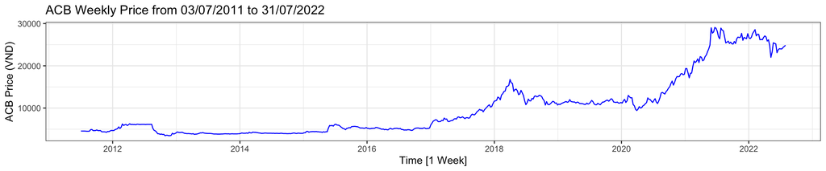

```r
ACB_sorted %>% ggplot() + aes(x = `Date`, y =`Price`,group = 1) +
  geom_line(color = "blue", size = 0.5) +
  ggtitle("ACB Weekly Price from 03/07/2011 to 31/07/2022") +
  theme_bw() + xlab("Time [1 Week]") + ylab("ACB Price (VND)")
```

Moreover, the spike in stock price owing to invalid value might also resulted in following invalid Stock Returns value, as Returns are calculated from stock prices. Consequently, it is better to validate the Return (“Change..”) variable:

```r
summary(ACB_sorted$Change..[ACB_sorted$Date > "2015-01-01" & ACB_sorted$Date < "2016-01-01"])
```

```
##      Min.   1st Qu.    Median      Mean   3rd Qu.      Max.
## -0.736200 -0.015700  0.000000 -0.008061  0.018150  0.198800
```

```r
print(ACB_sorted$Date[ACB_sorted$Change.. == min(ACB_sorted$Change..)])
```

```
## [1] "2015-02-22"
```

```r
#The invalid negative return is at week 2015-02-22
```

According to the summary result, there is an abnormal negative weekly return of -73.62%, which is clearly resulted from invalid data. Hence, the row which contains the invalid return should also be removed.

```r
ACB_sorted <- subset(ACB_sorted,Date != "2015-02-22")
```

### I. Introduction

The goal of this research is to examine the relationship between future and past (lagged) stock returns of Asia Commercial Bank (ACB) and Vietnam Export Import Commercial Joint Stock Bank (EIB). These banks are both created in the 1990s, currently two of the ten largest banks in Vietnam (Vietnam Plus 2022), serving commercial banking, institutional banking, and consumer banking (Vietstock n.d). Then, it provides trustworthy forecast model for substantial-monetary-benefits.

To investigate the relationship, we chose to use return data from 10-July-2011 to 31-July-2022 in Weekly intervals for the most sufficient dataset, which later will be effective for our finding. Firstly, we plot the ACF from the 2 banks’ returns for comparisons and discussion based on the findings from the Descriptive Statistic. Finally, the predictive power of past return (RETLAG) on future return (RET) will be tested using the Arima regression model. Macroeconomic indicators reveal a country’s overall economic strength or weakness (Alam 2014), therefore they serve as leading indications of stock returns. Tu (2012) stated in the banking sector, because stock prices rise when inflation rates do, increasing dividend payments and providing shareholders with a higher return, the inflation rate has a positive but insignificant impact on the ROE (Return-On-Equity). The money supply (M2) has an insignificant but negative influence on the stock return, as money supply growth will result in higher interest rates, which will encourage more saving and deposits (Garnia et al 2022). Additionally, the interest rate has a negative and significant effect on the stock return since as interest rates rise, people will prefer saving money than investing (Paul et al 2003). Changes in market return are statistically significant and have a positive impact on stock returns. The exchange rate and GDP also have a positive relationship with the stock return because capital inflows will flood into stocks if the national currency increases, and investors will wait for a suitable opportunity to receive higher market returns. Gold price has a significant positive relationship with the stock return, as the findings of Ismi (2018) show that when the gold price is high, investors will also buy stocks so that their portfolio varies with the purpose of decreasing risk because gold is recognized to have minimal risk (Erna et al 2022).

Besides the effect of external factors, internal factors such as company finance performance and dividend policy could reflect the stock price. Particularly, ROA (Return-on-Assets) indicates how profitable a company is in relation to all owed assets. The higher ROA ratio shows that firms are increasingly effective in using assets to gain net income after tax and this is a good signal about financial performance of firm (Subing et al 2017). This attracts more potential investors due to a higher return, leading to an increase in banking stock’s price. Regards dividend policy, those companies that have a high dividend payment would be valued more highly, in comparison to the companies with a low dividend payment (Chu 2020). Specifically, an increase in dividend payment might be good news for the financial situation of firm and brighter prospects. Thus, the increase in expectation of investors boosts of stock market price.

### III. Stock Charting and Descriptive Statistics

1. **Stock Return Time Plot**

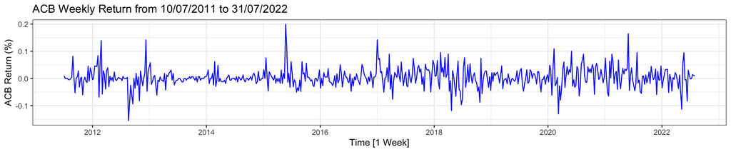

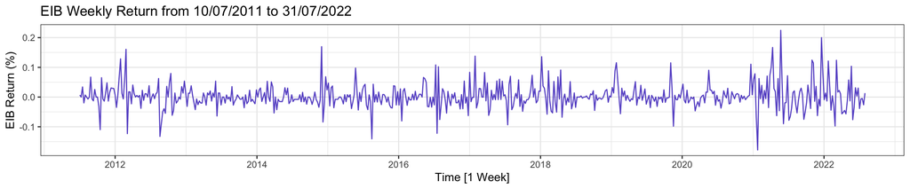

   ```r
   ACB_sorted %>% ggplot() + aes(y=`Change..`, x= `Date`) +
     geom_line(color = "blue", size = 0.5) +
     ggtitle("ACB Weekly Return from 10/07/2011 to 31/07/2022") +
     theme_bw() +xlab("Time [1 Week]") + ylab("ACB Return (%)")
   ```

2. **Descriptive Statistic of Stock Weekly Returns**
- **Descriptive Statistic Result**

```r
summary(ACB_sorted$Change..)
```

```
##      Min.   1st Qu.    Median      Mean   3rd Qu.      Max.
## -0.155000 -0.013000  0.000000  0.003644  0.021050  0.198800
```

```r
summary(EIB_sorted$Change..)
```

```
##      Min.   1st Qu.    Median      Mean   3rd Qu.      Max.
## -0.178000 -0.016800  0.000000  0.002428  0.018000  0.224600
```

- **Histogram of Stock Weekly Returns**

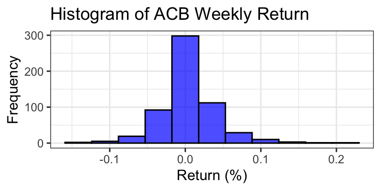

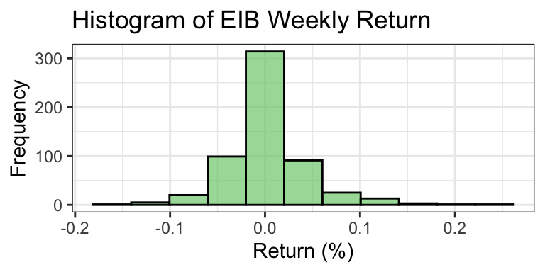

- **Box Plot of Stock Weekly Returns**

[figure not shown]

[figure not shown]